# 大數據分析方法

May 23, 2016

## 作業相關

## 成績

已請助教回覆，如果有問題的話可以下課或寫信給我或助教。

## 報告….

- 抄範例也要記得`改錯字`啊….
- 抄範例也要記得拿掉`沒用的Code和註解`啊…..
- 5/30 報告的兩組，如果要畢業典禮前拿到成績，這次的作業要提早交

## 基本的R觀念：`Packages`

R = `主程式`加上一大堆`Packages`

要用特殊的`功能函數`，有時需要另外安裝`packages`，如果出現找不到『Package名稱』的錯誤，可能就是沒安裝過（或是打錯字）。

安裝Packages範例：

```r
install.packages("ggplot2") ##有引號
```

出現找不到『要用的函數名稱』，可能是沒有載入packages（或是打錯字）。

載入Packages範例：

```r
library(ggplot2) ##不用引號
```

## 基本的R Code: subset 子集

```r
Data[選Row,選Column]
Data[選Row,]$選Column
```

選擇方式包括：

1. TRUE or FALSE 向量
2. index（像是只要單數Row，就填入c(1,3,5,7…..)）
3. Row names or Column names向量

## 基本的R Code: subset 子集

選擇方式包括：

1. TRUE or FALSE 向量
2. index（像是只要單數Row，就填入c(1,3,5,7…..)）
3. Row names or Column names向量

```r
Data[c(1:3),c(2:4)] # Data[選Row,選Column], index 向量
Data[Data$Select="AA",]$Score #Data[選Row,]$選Column, T/F 向量
Data[Data$Select="AA","Score"] #Data[選Row,選Column], T/F 向量+Column names
```

## Markdown vs. R Markdown

開GitHub看就知道差別

- Markdown: 在GitHub上呈現成果
- R Markdown: 利用R，製造Markdown文件

`R Markdown`不只能用在製造`Markdown`文件，也可以做`Slides`，或是`網頁`）

比如說… https://yijutseng.shinyapps.io/Name/

## 點名神器原始碼

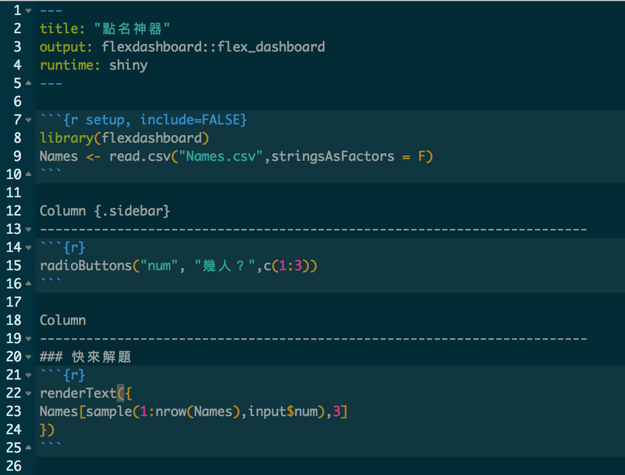

## ML 複習

## Supervised learning 監督式學習 -1

- Regression 迴歸
  - Linear Regression 線性迴歸 `Y~X1+X2`，Y連續
  - `glm(Y~X1+X2, data=DATA, method='gaussian')`
  - Logistic Regression 邏輯迴歸 `Y~X1+X2`，Y二元
  - `glm(Y~X1+X2, data=DATA, method='binomial')`
  - 若自變項X是類別變項，需要建立`虛擬變項`。`R: 轉成factor`

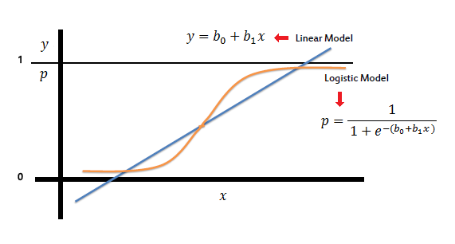

## Supervised learning 監督式學習 -2

- Classification 分類
  - Support Vector Machines 支持向量機
  - Decision Trees 決策樹 `rpart(Y~X1+X2, data=DATA)`
  - Neural Networks 神經網路
  - K-Nearest Neighbor

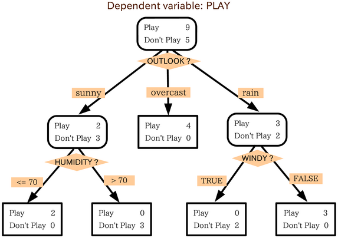

## Unsupervised learning 非監督式學習

- Clustering 分群
  - Hierarchical clustering 階層式分群 `hclust()`
  - K-means clustering `kmeans()`
- Association Rules 關聯式規則 `apriori()`, from `arules` package

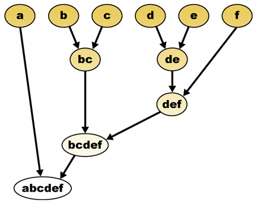

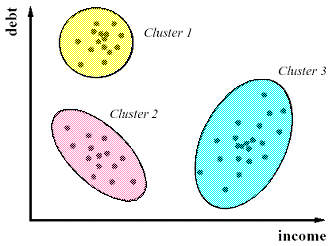

## 上課用程式碼

[Rmd下載](https://github.com/yijutseng/BigDataCGUIM/blob/master/BigData20160523.Rmd)

按Raw，右鍵另存新檔

投影片下載：

[Html下載](https://raw.githubusercontent.com/yijutseng/BigDataCGUIM/master/BigData20160523.html)

按右鍵，另存新檔

## Association Rules 關聯式規則

## 什麼是關聯式規則？

- 用於從大量數據中挖掘出有價值的數據項之間的相關關係
- 不考慮項目的次序，而僅考慮其組合
- `購物籃分析 (Market Basket Analysis)`
- Apriori演算法是挖掘`布林關聯規則` (Boolean association rules) 頻繁項集的算法

## Apriori演算法

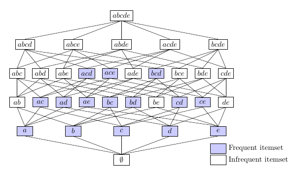

## 超市資料分析：讀取資料

```r
# Load the libraries
if (!require('arules')){
    install.packages("arules");library(arules) #for Apriori演算法
}
if (!require('datasets')){
    install.packages("datasets");library(datasets) #for Groceries data
}
data(Groceries) # Load the data set
Groceries@data@Dim #169 種商品，9835筆交易資料
```

```
## [1]  169 9835
```

## 超市資料長這樣

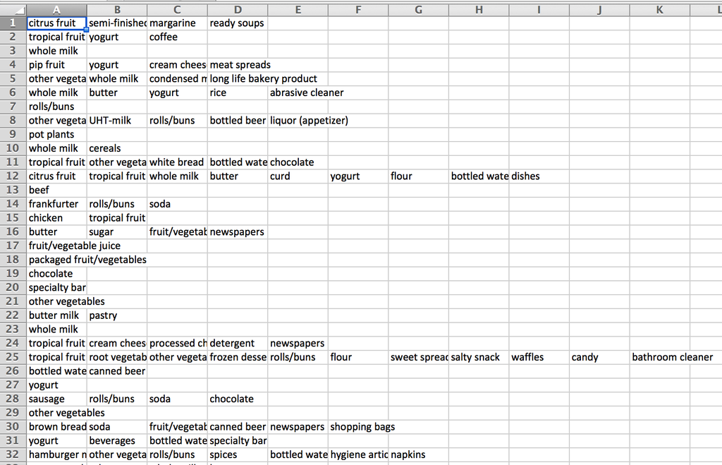

## 超市資料分析：關聯式分析`apriori()`

```r
# Get the rules
rules <- apriori(Groceries, # data= Groceries
                 parameter = list(supp = 0.001, conf = 0.8), #參數最低限度
                 control = list(verbose=F)) #不要顯示output
options(digits=2) # Only 2 digits
inspect(rules[1:5]) # Show the top 5 rules
```

```
##   lhs                        rhs            support confidence lift
## 1 {liquor,red/blush wine} => {bottled beer} 0.0019  0.90       11.2
## 2 {curd,cereals}          => {whole milk}   0.0010  0.91        3.6
## 3 {yogurt,cereals}        => {whole milk}   0.0017  0.81        3.2
## 4 {butter,jam}            => {whole milk}   0.0010  0.83        3.3
## 5 {soups,bottled beer}    => {whole milk}   0.0011  0.92        3.6
```

## 如何解讀模型

啤酒=>尿布

- `Support`: 一次交易中，包括規則內的物品的機率。買啤酒同時買尿布的機率。交集
- `Confidence`: 包含左邊物品A的交易也會包含右邊物品B的條件機率。在買了啤酒的顧客中，有買尿布的比例。
- `Lift`: 規則的信心比期望值高多少。（買了啤酒以後，有買尿布的機率）/（在所有顧客群中買尿布的機率）
  - `lift`=1: items on the left and right are independent.

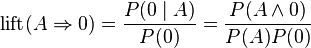

## 列出最有關連的幾條規則

```r
rules<-sort(rules, by="confidence", decreasing=TRUE) #按照confidence排序
inspect(rules[1:5]) # Show the top 5 rules
```

```
##   lhs                     rhs          support confidence lift
## 1 {rice,
##    sugar}              => {whole milk}  0.0012          1  3.9
## 2 {canned fish,
##    hygiene articles}   => {whole milk}  0.0011          1  3.9
## 3 {root vegetables,
##    butter,
##    rice}               => {whole milk}  0.0010          1  3.9
## 4 {root vegetables,
##    whipped/sour cream,
##    flour}              => {whole milk}  0.0017          1  3.9
## 5 {butter,
##    soft cheese,
##    domestic eggs}      => {whole milk}  0.0010          1  3.9
```

## 特別針對某項商品，右邊

買了什麼東西的人，會買`牛奶`呢？

```r
rulesR<-apriori(data=Groceries, parameter=list(supp=0.001,conf = 0.08),
        appearance = list(default="lhs",rhs="whole milk"), #設定右邊一定要是牛奶
        control = list(verbose=F)) #不要顯示output
rulesR<-sort(rulesR, decreasing=TRUE,by="confidence") #按照confidence排序
inspect(rulesR[1:5]) # Show the top 5 rules
```

```
##   lhs                     rhs          support confidence lift
## 1 {rice,
##    sugar}              => {whole milk}  0.0012          1  3.9
## 2 {canned fish,
##    hygiene articles}   => {whole milk}  0.0011          1  3.9
## 3 {root vegetables,
##    butter,
##    rice}               => {whole milk}  0.0010          1  3.9
## 4 {root vegetables,
##    whipped/sour cream,
##    flour}              => {whole milk}  0.0017          1  3.9
## 5 {butter,
##    soft cheese,
##    domestic eggs}      => {whole milk}  0.0010          1  3.9
```

## 特別針對某項商品，左邊

買了`牛奶`的人，會買什麼呢？

```r
rulesL<-apriori(data=Groceries, parameter=list(supp=0.001,conf = 0.15,minlen=2),
        appearance = list(default="rhs",lhs="whole milk"), #設定左邊一定要是牛奶
        control = list(verbose=F)) #不要顯示output
rulesL<-sort(rulesL, decreasing=TRUE,by="confidence") #按照confidence排序
inspect(rulesL[1:5]) # Show the top 5 rules
```

```
##   lhs             rhs                support confidence lift
## 6 {whole milk} => {other vegetables} 0.075   0.29       1.5
## 5 {whole milk} => {rolls/buns}       0.057   0.22       1.2
## 4 {whole milk} => {yogurt}           0.056   0.22       1.6
## 2 {whole milk} => {root vegetables}  0.049   0.19       1.8
## 1 {whole milk} => {tropical fruit}   0.042   0.17       1.6
```

## 規則視覺化

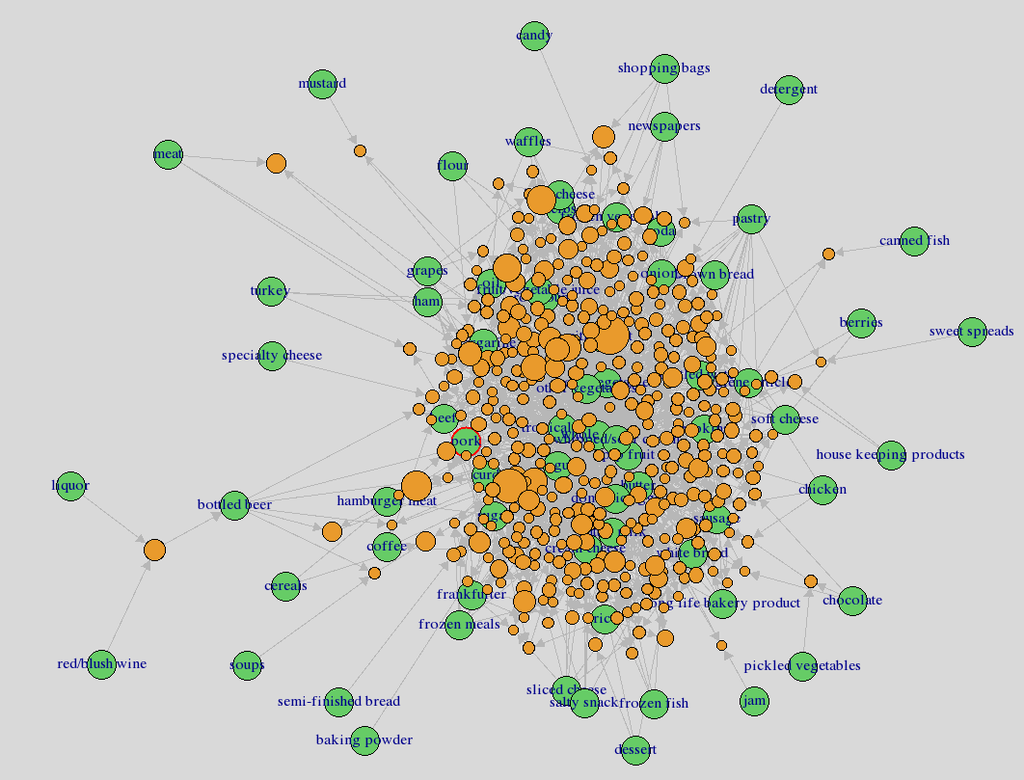

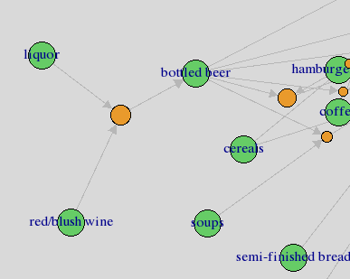

```r
if (!require('arulesViz')){
    install.packages("arulesViz"); library(arulesViz)
}
#Mac->http://planspace.org/2013/01/17/fix-r-tcltk-dependency-problem-on-mac/
plot(rules,method="graph",interactive=TRUE,shading=NA) #會跑一陣子
```

## 參考資料

- 台大資工林軒田教授（田神）：
  - Machine Learning Foundations
  - Machine Learning Techniques
- [Market Basket Analysis with R](http://www.salemmarafi.com/code/market-basket-analysis-with-r/)

## 模型驗證？！

- Training set, Development set: 讓演算法`學`到`知識`
- Test set, Validation set: 驗證`學`的怎麼樣
- 通常會比例分配
  - 2/3的資料設為`Training set`
  - 剩下的1/3做驗證`Test set`

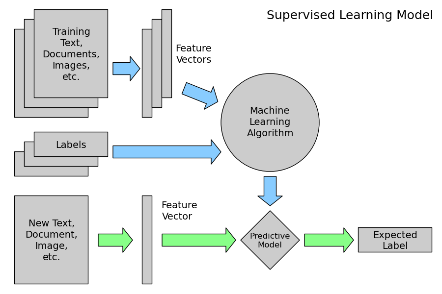

## 把NBA的資料讀入

```r
#讀入SportsAnalytics package
if (!require('SportsAnalytics')){
    install.packages("SportsAnalytics")
    library(SportsAnalytics)
}
#擷取2015-2016年球季球員資料
NBA1516<-fetch_NBAPlayerStatistics("15-16")
NBA1516<-NBA1516[complete.cases(NBA1516),]
```

## Regression 迴歸

## 哪個模型比較好？

```r
OneVar<-glm(TotalPoints~TotalMinutesPlayed,data =NBA1516)
TwoVar<-glm(TotalPoints~TotalMinutesPlayed+FieldGoalsAttempted,
            data =NBA1516)
ThreeVar<-glm(TotalPoints~TotalMinutesPlayed+FieldGoalsAttempted+Position,
              data =NBA1516)
c(OneVar$aic,TwoVar$aic,ThreeVar$aic)
```

```
## [1] 6326 5356 5322
```

## 好！？

- 以Training set來`選看起來最好的模型`
- 用Test set來`驗證模型是不是真的很好`
- 想像…..訓練出來題庫答得好的學生，寫到新題目不一定會寫！？

## 隨機抽樣？

```r
sample(1:10,3) # 從1到10，隨機取三個數字
```

```
## [1] 9 1 8
```

```r
sample(1:nrow(NBA1516),nrow(NBA1516)/3) #從第一行到最後一行，隨機取1/3行數
```

```
##   [1] 161 297 197 186 209  22 390 241 191 412 100 158 204 433 208 243 312
##  [18] 165 329 369 399 181 443 205 106 240 278 324  57 265 285 221  32 403
##  [35] 166 348 380 196 277  78 172 180 289 392 296  77  23 300 202 142 244
##  [52] 431 358 258  46 401  20 201 280  94  71 363 328 447  27 121 407 306
##  [69] 125 141 223 314 200  93 270 446 282  37 474 384 133 122 349 378 454
##  [86]  53 138  52 359 335  72 370 311 416 271 291 340  48 419 126 173 212
## [103] 404 400  87  68 235 389 193 154 113 294 275 461 468 336 408 199 226
## [120] 164 437   8 284  15 218 147 146 318  39 385  69 332 351  64 394 171
## [137]  10  88 128  97 347 109 406 302 430 117 304  21   7 424 210 184 319
## [154] 317  80 261 214 131
```

## 把NBA的資料分成Training 和 Test set

```r
NBA1516$Test<-F #新增一個參數紀錄分組
#隨機取1/3當Test set
NBA1516[sample(1:nrow(NBA1516),nrow(NBA1516)/3),]$Test<-T
# Training set : Test set球員數
c(sum(NBA1516$Test==F),sum(NBA1516$Test==T))
```

```
## [1] 317 158
```

## 訓練一個多變數線性迴歸模型

```r
fit<-glm(TotalPoints~TotalMinutesPlayed+FieldGoalsAttempted+
             Position+ThreesAttempted+FreeThrowsAttempted,
              data =NBA1516[NBA1516$Test==F,])
fit$aic
```

```
## [1] 3266
```

```r
summary(fit)$coefficients
```

```
##                     Estimate Std. Error t value Pr(>|t|)
## (Intercept)          1.3e+01     7.5591  1.6926  9.2e-02
## TotalMinutesPlayed  -1.1e-05     0.0074 -0.0015  1.0e+00
## FieldGoalsAttempted  1.0e+00     0.0219 45.5537 7.0e-139
## PositionPF          -2.0e+01     8.0062 -2.5290  1.2e-02
## PositionPG          -4.0e+01     8.6229 -4.6188  5.7e-06
## PositionSF          -2.3e+01     8.8320 -2.6014  9.7e-03
## PositionSG          -3.0e+01     8.8318 -3.4075  7.4e-04
## ThreesAttempted      1.4e-01     0.0288  4.7732  2.8e-06
## FreeThrowsAttempted  7.2e-01     0.0346 20.7758  1.5e-60
```

## 逐步選擇模型 stepwise

後退學習：一開始先將所有參數加到模型裡，再一個一個拿掉

```r
library(MASS)
##根據AIC，做逐步選擇, 預設倒退學習 direction = "backward"
##trace=FALSE: 不要顯示步驟
finalModel_B<-stepAIC(fit,direction = "backward",trace=FALSE)
summary(finalModel_B)$coefficients
```

```
##                     Estimate Std. Error t value Pr(>|t|)
## (Intercept)            12.79      7.002     1.8  6.9e-02
## FieldGoalsAttempted     1.00      0.016    61.0 2.0e-174
## PositionPF            -20.25      7.964    -2.5  1.1e-02
## PositionPG            -39.83      8.556    -4.7  4.8e-06
## PositionSF            -22.97      8.807    -2.6  9.5e-03
## PositionSG            -30.09      8.746    -3.4  6.6e-04
## ThreesAttempted         0.14      0.028     4.8  2.1e-06
## FreeThrowsAttempted     0.72      0.035    20.8  8.3e-61
```

## 逐步選擇模型 stepwise

往前學習：一開始先做一個沒有參數的模型，再把參數一個一個加進去

```r
##根據AIC，做逐步選擇, 往前學習 direction = "forward"
finalModel_F<-stepAIC(fit,direction = "forward",trace=FALSE)
summary(finalModel_F)$coefficients
```

```
##                     Estimate Std. Error t value Pr(>|t|)
## (Intercept)          1.3e+01     7.5591  1.6926  9.2e-02
## TotalMinutesPlayed  -1.1e-05     0.0074 -0.0015  1.0e+00
## FieldGoalsAttempted  1.0e+00     0.0219 45.5537 7.0e-139
## PositionPF          -2.0e+01     8.0062 -2.5290  1.2e-02
## PositionPG          -4.0e+01     8.6229 -4.6188  5.7e-06
## PositionSF          -2.3e+01     8.8320 -2.6014  9.7e-03
## PositionSG          -3.0e+01     8.8318 -3.4075  7.4e-04
## ThreesAttempted      1.4e-01     0.0288  4.7732  2.8e-06
## FreeThrowsAttempted  7.2e-01     0.0346 20.7758  1.5e-60
```

## 逐步選擇模型 stepwise

雙向學習：參數加加減減

```r
##根據AIC，做逐步選擇, 雙向學習 direction = "both"
finalModel_Both<-stepAIC(fit,direction = "both",trace=FALSE)
summary(finalModel_Both)$coefficients
```

```
##                     Estimate Std. Error t value Pr(>|t|)
## (Intercept)            12.79      7.002     1.8  6.9e-02
## FieldGoalsAttempted     1.00      0.016    61.0 2.0e-174
## PositionPF            -20.25      7.964    -2.5  1.1e-02
## PositionPG            -39.83      8.556    -4.7  4.8e-06
## PositionSF            -22.97      8.807    -2.6  9.5e-03
## PositionSG            -30.09      8.746    -3.4  6.6e-04
## ThreesAttempted         0.14      0.028     4.8  2.1e-06
## FreeThrowsAttempted     0.72      0.035    20.8  8.3e-61
```

## 用Test set來評估模型好不好

```r
predictPoint<-predict(finalModel_Both, #Test==T, test data
                      newdata = NBA1516[NBA1516$Test==T,])
cor(x=predictPoint,y=NBA1516[NBA1516$Test==T,]$TotalPoints) #相關係數
```

```
## [1] 1
```

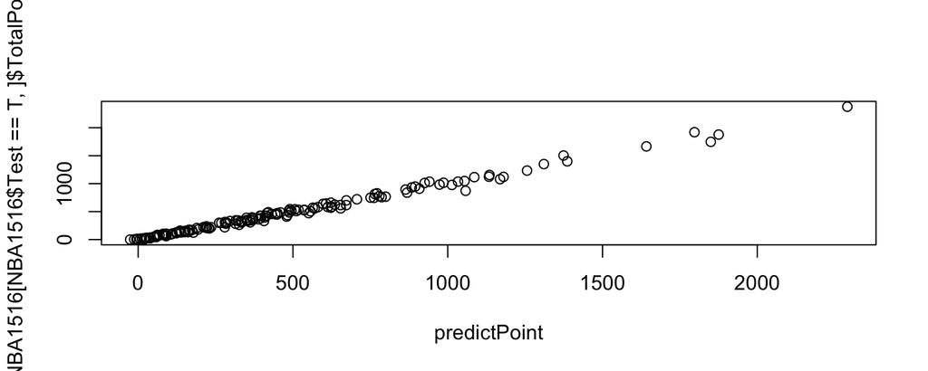

```r
plot(x=predictPoint,y=NBA1516[NBA1516$Test==T,]$TotalPoints)
```

## Logistic Regression 邏輯迴歸

## 把入學資料分成Training 和 Test set

注意：當答案有正反兩面時，`Level 1 要放正面答案`–>有病/錄取…

```r
mydata <- read.csv("http://www.ats.ucla.edu/stat/data/binary.csv")
mydata$admit <- factor(mydata$admit) # 類別變項要轉為factor
mydata$rank <- factor(mydata$rank) # 類別變項要轉為factor
mydata$Test<-F #新增一個參數紀錄分組
mydata[sample(1:nrow(mydata),nrow(mydata)/3),]$Test<-T #隨機取1/3當Test set
c(sum(mydata$Test==F),sum(mydata$Test==T)) # Training set : Test set學生數
```

```
## [1] 267 133
```

```r
#修改一下factor的level: 改成Level 1為錄取，2為不錄取-->Level 1 要放正面答案
mydata$admit<-factor(mydata$admit,levels=c(1,0))
```

## 逐步選擇最好的模型

```r
# GRE:某考試成績, GPA:在校平均成績, rank:學校聲望
mylogit <- glm(admit ~ gre + gpa + rank,
               data = mydata[mydata$Test==F,], family = "binomial")
finalFit<-stepAIC(mylogit,direction = "both",trace=FALSE) # 雙向逐步選擇模型
summary(finalFit)
```

```
##
## Call:
## glm(formula = admit ~ gre + gpa + rank, family = "binomial",
##     data = mydata[mydata$Test == F, ])
##
## Deviance Residuals:
##    Min      1Q  Median      3Q     Max
## -2.106  -1.059   0.627   0.844   1.689
##
## Coefficients:
##             Estimate Std. Error z value Pr(>|z|)
## (Intercept)  4.04096    1.40431    2.88  0.00401 **
## gre         -0.00210    0.00135   -1.55  0.12041
## gpa         -0.88568    0.40528   -2.19  0.02886 *
## rank2        0.85349    0.37715    2.26  0.02364 *
## rank3        1.52571    0.41639    3.66  0.00025 ***
## rank4        1.65705    0.50179    3.30  0.00096 ***
## ---
## Signif. codes:  0 '***' 0.001 '**' 0.01 '*' 0.05 '.' 0.1 ' ' 1
##
## (Dispersion parameter for binomial family taken to be 1)
##
##     Null deviance: 332.54  on 266  degrees of freedom
## Residual deviance: 300.93  on 261  degrees of freedom
## AIC: 312.9
##
## Number of Fisher Scoring iterations: 4
```

## 來預測一下新學生可不可以錄取

```r
AdmitProb<-predict(finalFit, # 用Training set做的模型
                   newdata = mydata[mydata$Test==T,], #Test==T, test data
                   type="response") #結果為每個人被錄取的機率
head(AdmitProb)
```

```
##    2    4    8   11   16   19
## 0.24 0.47 0.44 0.29 0.70 0.63
```

```r
table(AdmitProb<0.5,mydata[mydata$Test==T,]$admit) # row,column
```

```
##
##          1  0
##   FALSE 28 84
##   TRUE  13  8
```

## 當答案是二元時：效能指標

- Sensitivity 敏感性
- Specificity 特異性
- Positive Predictive Value (PPV) 陽性預測值
- Negative Predictive Value (NPV) 陰性預測值

## 名詞解釋

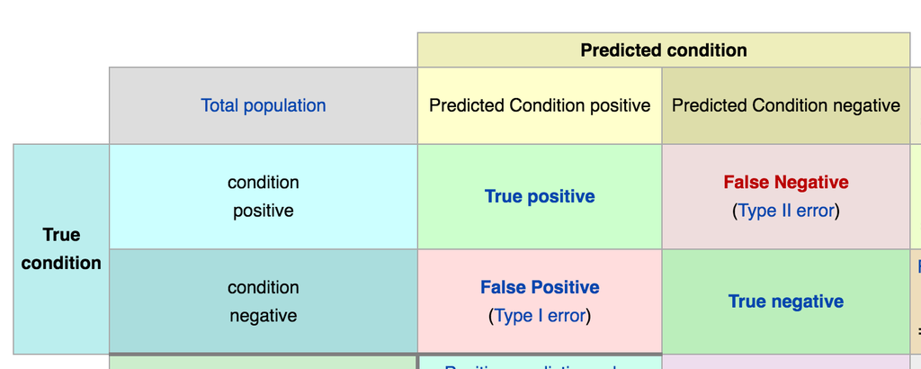

- TP: 有病且預測也有病
- TN: 沒病且預測也沒病
- FP: 沒病但是預測有病
- FN: 有病但預測沒病

## 當答案是二元時：效能指標公式

- Sensitivity 敏感性：所有`真的有病`的人，被`預測有病`的比例
- Specificity 特異性：所有`真的沒病`的人，被`預測沒病`的比例
- Positive Predictive Value (PPV) 陽性預測值：所有被`預測有病`的人，`真的有病`的比例
- Negative Predictive Value (NPV) 陰性預測值：所有被`預測沒病`的人，`真的沒病`的比例

## 回想一下剛剛的驗證結果

```r
table(AdmitProb<0.5,mydata[mydata$Test==T,]$admit) # row,column
```

```
##
##          1  0
##   FALSE 28 84
##   TRUE  13  8
```

## 計算預測效能參數

```r
AdmitProb<-predict(finalFit,
                   newdata = mydata[mydata$Test==T,], #Test==T, test data
                   type="response") #結果為每個人『不』被錄取的機率
AdmitAns<-factor(ifelse(AdmitProb<0.5,1,0),levels=c(1,0))
str(AdmitAns)
```

```
##  Factor w/ 2 levels "1","0": 1 1 1 1 2 2 2 2 2 2 ...
##  - attr(*, "names")= chr [1:133] "2" "4" "8" "11" ...
```

## 計算預測效能參數

```r
library(caret) # install.packages("caret") #計算參數的packages
sensitivity(AdmitAns,mydata[mydata$Test==T,]$admit)
```

```
## [1] 0.32
```

```r
specificity(AdmitAns,mydata[mydata$Test==T,]$admit)
```

```
## [1] 0.91
```

```r
posPredValue(AdmitAns,mydata[mydata$Test==T,]$admit)
```

```
## [1] 0.62
```

```r
negPredValue(AdmitAns,mydata[mydata$Test==T,]$admit)
```

```
## [1] 0.75
```

## 資料介紹: 糖尿病資料集

- Description: Predict the onset of diabetes in female Pima Indians from medical record data.
  - Type: Binary Classification
  - Dimensions: 768 instances, 9 attributes
  - Inputs: Numeric
  - Output: Categorical, 2 class labels

## 資料介紹: 糖尿病資料集

1. Number of times pregnant
2. Plasma glucose concentration a 2 hours in an oral glucose tolerance test
3. Diastolic blood pressure (mm Hg)
4. Triceps skin fold thickness (mm)
5. 2-Hour serum insulin (mu U/ml)
6. Body mass index (weight in kg/(height in m)^2)
7. Diabetes pedigree function
8. Age (years)
9. Class variable (0 or 1)

## 資料介紹: 糖尿病資料集

```r
#install.packages("mlbench") # 此package內有很多dataset可練習
library(mlbench)
data(PimaIndiansDiabetes)#雙號
str(PimaIndiansDiabetes) #diabetes: pos陽性/neg陰性
```

```
## 'data.frame':    768 obs. of  9 variables:
##  $ pregnant: num  6 1 8 1 0 5 3 10 2 8 ...
##  $ glucose : num  148 85 183 89 137 116 78 115 197 125 ...
##  $ pressure: num  72 66 64 66 40 74 50 0 70 96 ...
##  $ triceps : num  35 29 0 23 35 0 32 0 45 0 ...
##  $ insulin : num  0 0 0 94 168 0 88 0 543 0 ...
##  $ mass    : num  33.6 26.6 23.3 28.1 43.1 25.6 31 35.3 30.5 0 ...
##  $ pedigree: num  0.627 0.351 0.672 0.167 2.288 ...
##  $ age     : num  50 31 32 21 33 30 26 29 53 54 ...
##  $ diabetes: Factor w/ 2 levels "neg","pos": 2 1 2 1 2 1 2 1 2 2 ...
```

## 資料介紹: 乳癌資料集

- Description: Predict whether a cancer is malignant or benign from biopsy details.
  - Type: Binary Classification
  - Dimensions: 699 instances, 11 attributes
  - Inputs: Integer (Nominal)
  - Output: Categorical, 2 class labels

## 資料介紹: 乳癌資料集

1. Sample code number: id number
2. Clump Thickness: 1 - 10 皮膚襞厚度
3. Uniformity of Cell Size: 1 - 10
4. Uniformity of Cell Shape: 1 - 10
5. Marginal Adhesion: 1 - 10 邊緣粘連
6. Single Epithelial Cell Size: 1 - 10
7. Bare Nuclei: 1 - 10
8. Bland Chromatin: 1 - 10
9. Normal Nucleoli: 1 - 10
10. Mitoses: 1 - 10 有絲分裂
11. Class: (2 for benign, 4 for malignant)

## 資料介紹: 乳癌資料集

```r
#install.packages("mlbench") # 此package內有很多dataset可練習
library(mlbench)
data(BreastCancer) #單號
str(BreastCancer) #Class: benign良性/malignant陰性
```

```
## 'data.frame':    699 obs. of  11 variables:
##  $ Id             : chr  "1000025" "1002945" "1015425" "1016277" ...
##  $ Cl.thickness   : Ord.factor w/ 10 levels "1"<"2"<"3"<"4"<..: 5 5 3 6 4 8 1 2 2 4 ...
##  $ Cell.size      : Ord.factor w/ 10 levels "1"<"2"<"3"<"4"<..: 1 4 1 8 1 10 1 1 1 2 ...
##  $ Cell.shape     : Ord.factor w/ 10 levels "1"<"2"<"3"<"4"<..: 1 4 1 8 1 10 1 2 1 1 ...
##  $ Marg.adhesion  : Ord.factor w/ 10 levels "1"<"2"<"3"<"4"<..: 1 5 1 1 3 8 1 1 1 1 ...
##  $ Epith.c.size   : Ord.factor w/ 10 levels "1"<"2"<"3"<"4"<..: 2 7 2 3 2 7 2 2 2 2 ...
##  $ Bare.nuclei    : Factor w/ 10 levels "1","2","3","4",..: 1 10 2 4 1 10 10 1 1 1 ...
##  $ Bl.cromatin    : Factor w/ 10 levels "1","2","3","4",..: 3 3 3 3 3 9 3 3 1 2 ...
##  $ Normal.nucleoli: Factor w/ 10 levels "1","2","3","4",..: 1 2 1 7 1 7 1 1 1 1 ...
##  $ Mitoses        : Factor w/ 9 levels "1","2","3","4",..: 1 1 1 1 1 1 1 1 5 1 ...
##  $ Class          : Factor w/ 2 levels "benign","malignant": 1 1 1 1 1 2 1 1 1 1 ...
```

## 作業步驟說明

## 步驟1.1: 讀資料，單號

```r
#install.packages("mlbench") # 此package內有很多dataset可練習
library(mlbench)
data(BreastCancer) #單號
head(BreastCancer) #Class: benign良性/malignant陰性
```

```
##        Id Cl.thickness Cell.size Cell.shape Marg.adhesion Epith.c.size
## 1 1000025            5         1          1             1            2
## 2 1002945            5         4          4             5            7
## 3 1015425            3         1          1             1            2
## 4 1016277            6         8          8             1            3
## 5 1017023            4         1          1             3            2
## 6 1017122            8        10         10             8            7
##   Bare.nuclei Bl.cromatin Normal.nucleoli Mitoses     Class
## 1           1           3               1       1    benign
## 2          10           3               2       1    benign
## 3           2           3               1       1    benign
## 4           4           3               7       1    benign
## 5           1           3               1       1    benign
## 6          10           9               7       1 malignant
```

## 步驟1.1: 讀資料，雙號

```r
#install.packages("mlbench") # 此package內有很多dataset可練習
library(mlbench)
data(PimaIndiansDiabetes) #雙號
head(PimaIndiansDiabetes) #diabetes: pos陽性/neg陰性
```

```
##   pregnant glucose pressure triceps insulin mass pedigree age diabetes
## 1        6     148       72      35       0   34     0.63  50      pos
## 2        1      85       66      29       0   27     0.35  31      neg
## 3        8     183       64       0       0   23     0.67  32      pos
## 4        1      89       66      23      94   28     0.17  21      neg
## 5        0     137       40      35     168   43     2.29  33      pos
## 6        5     116       74       0       0   26     0.20  30      neg
```

## 步驟1.2: 資料前處理

留下沒有缺值的資料，把無關病情的資料拿掉（像是ID）

```r
# 單號
BreastCancerC<-BreastCancer[complete.cases(BreastCancer), # 選資料完整的row
                            !names(BreastCancer) %in% c("Id")] #把Id拿掉
c(nrow(BreastCancer),nrow(BreastCancerC))
```

```
## [1] 699 683
```

```r
PimaIndiansDiabetesC<- #雙號
    PimaIndiansDiabetes[complete.cases(PimaIndiansDiabetes),] # 選資料完整的row
c(nrow(PimaIndiansDiabetes),nrow(PimaIndiansDiabetesC))
```

```
## [1] 768 768
```

## 步驟2:分成訓練組與測試組

該怎麼分可以自己決定，1/3，1/5…都可以

```r
BreastCancerC$Test<-F #新增一個參數紀錄分組
#隨機取1/3當Test set
BreastCancerC[
    sample(1:nrow(BreastCancerC),nrow(BreastCancerC)/3),
     ]$Test<-T
# 看一下 Training set : Test set 病人數
c(sum(BreastCancerC$Test==F),sum(BreastCancerC$Test==T))
```

```
## [1] 456 227
```

## 步驟3:訓練模型

- 注意只能用`訓練組`的資料，`Test`參數==F，忘記可以看前面範例

模型選擇建議：

- 糖尿病資料：回歸？ `glm()`
  - formula: diabetes~. 『`.`』代表全部參數
- 乳癌資料：決策樹？ `rpart()` 需要安裝和使用`rpart` package
  - formula: Class~.
- 都試試看？–選一個好的？

提示：要預測的結果，是`二元類別變項` （pos/neg, benign/malignant）

## 步驟4:用測試組驗證模型

計算以下效能指標：

- Sensitivity
- Specificity
- Positive Predictive Value (PPV)
- Negative Predictive Value (NPV)

## 評分標準 1

- Title：乳癌/糖尿病 預測模型 (`5 pt`)
- 次標題1：資料前處理 (`20 pt`)
  - 解釋資料 (`10 pt`) –可參考`資料介紹`
  - 把資料讀進來 (`5 pt`)
  - 分成訓練組跟測試組，並紀錄各組人數 (`5 pt`)
- 次標題2：預測模型建立 (`35 pt`)
  - 模型建立、挑選、說明 (`20 pt`)
  - 模型呈現與說明 (`15 pt`)

## 評分標準 2

- 次標題3：預測模型驗證，解釋 (`40 pt`) –依效能給分
  - Sensitivity (`10 pt`)
  - Specificity (`10 pt`)
  - Positive Predictive Value (PPV) (`10 pt`)
  - Negative Predictive Value (NPV) (`10 pt`)

## 作業7範例 - 完整的Rmd & md檔

範例是用`"礦石"`資料，跟作業不同，要參考的話記得要改說明/資料來源….等等等

[Rmd下載](https://github.com/yijutseng/BigDataCGUIM/blob/master/HW7.Rmd)

[md下載](https://github.com/yijutseng/BigDataCGUIM/blob/master/HW7.md)

## Decision Trees 決策樹

## 阻攻/籃板/三分/助攻/抄截判斷位置-訓練

```r
if (!require('rpart')){
    install.packages("rpart"); library(rpart)
}
DT<-rpart(Position~Blocks+TotalRebounds+ThreesMade+Assists+Steals,
          data=NBA1516[NBA1516$Test==F,]) #訓練組 Training set
#控球後衛（PG）、得分後衛（SG）、小前鋒（SF）、大前鋒（PF）和中鋒（C）
DT
```

```
## n= 317
##
## node), split, n, loss, yval, (yprob)
##       * denotes terminal node
##
##   1) root 317 240 PF (0.15 0.24 0.21 0.18 0.23)
##     2) ThreesMade< 2.5 85  48 C (0.44 0.38 0.071 0.047 0.071)
##       4) Blocks>=9 54  21 C (0.61 0.39 0 0 0)
##         8) Assists< 40 24   6 C (0.75 0.25 0 0 0) *
##         9) Assists>=40 30  15 C (0.5 0.5 0 0 0)
##          18) TotalRebounds>=5.1e+02 12   2 C (0.83 0.17 0 0 0) *
##          19) TotalRebounds< 5.1e+02 18   5 PF (0.28 0.72 0 0 0) *
##       5) Blocks< 9 31  20 PF (0.13 0.35 0.19 0.13 0.19)
##        10) ThreesMade< 0.5 20  11 PF (0.2 0.45 0.1 0.2 0.05) *
##        11) ThreesMade>=0.5 11   6 SG (0 0.18 0.36 0 0.45) *
##     3) ThreesMade>=2.5 232 160 SG (0.039 0.19 0.26 0.22 0.29)
##       6) Assists>=1.9e+02 53  20 PG (0.019 0.057 0.62 0.11 0.19)
##        12) TotalRebounds< 3.4e+02 37   6 PG (0 0 0.84 0.054 0.11) *
##        13) TotalRebounds>=3.4e+02 16  10 SG (0.062 0.19 0.12 0.25 0.37) *
##       7) Assists< 1.9e+02 179 120 SG (0.045 0.22 0.15 0.26 0.32)
##        14) TotalRebounds>=2.8e+02 41  22 PF (0.12 0.46 0 0.32 0.098)
##          28) Steals< 60 25   7 PF (0.12 0.72 0 0.16 0) *
##          29) Steals>=60 16   7 SF (0.12 0.062 0 0.56 0.25) *
##        15) TotalRebounds< 2.8e+02 138  84 SG (0.022 0.15 0.2 0.24 0.39)
##          30) Assists< 84 93  59 SG (0.022 0.23 0.075 0.31 0.37)
##            60) TotalRebounds>=96 47  29 PF (0.043 0.38 0.021 0.3 0.26)
##             120) Steals< 34 32  15 PF (0.063 0.53 0.031 0.25 0.12)
##               240) ThreesMade< 19 10   1 PF (0.1 0.9 0 0 0) *
##               241) ThreesMade>=19 22  14 PF (0.045 0.36 0.045 0.36 0.18)
##                 482) TotalRebounds>=1.5e+02 11   3 PF (0.091 0.73 0 0.18 0) *
##                 483) TotalRebounds< 1.5e+02 11   5 SF (0 0 0.091 0.55 0.36) *
##             121) Steals>=34 15   7 SG (0 0.067 0 0.4 0.53) *
##            61) TotalRebounds< 96 46  24 SG (0 0.065 0.13 0.33 0.48) *
##          31) Assists>=84 45  25 PG (0.022 0 0.44 0.089 0.44)
##            62) TotalRebounds< 1.3e+02 16   2 PG (0 0 0.88 0.062 0.062) *
##            63) TotalRebounds>=1.3e+02 29  10 SG (0.034 0 0.21 0.1 0.66) *
```

## 阻攻/籃板/三分/助攻/抄截判斷位置-訓練

預設的`plot()`真的太難用，改用`rpart.plot` package的`prp()`

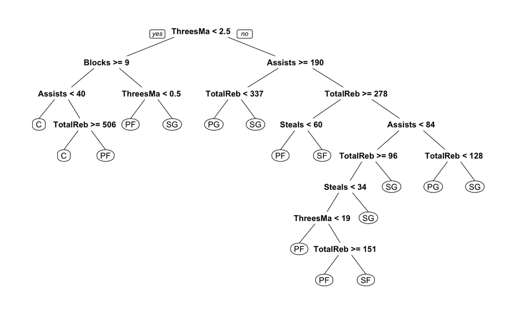

```r
if (!require('rpart.plot')){
    install.packages("rpart.plot"); library(rpart.plot)
}
prp(DT) # 把決策樹畫出來
```

## 阻攻/籃板/三分/助攻/抄截判斷位置-訓練

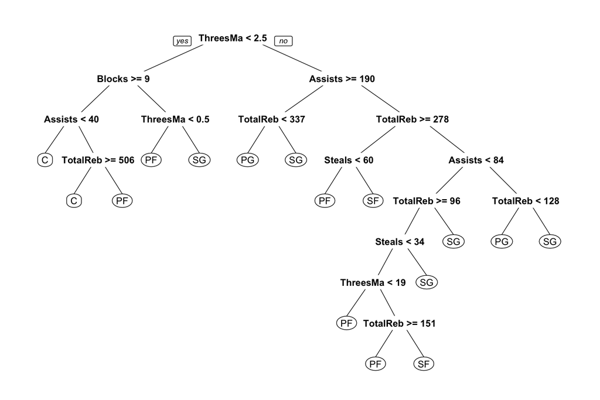

```r
prp(DT)
```

## 有批球員沒寫守備位置？–預測

```r
posPred<-predict(DT,newdata= NBA1516[NBA1516$Test==T,]) #Test==T, test data
# 預設為class probabilities, type = "prob"
head(posPred)
```

```
##        C    PF   PG   SF   SG
## 1  0.750 0.250 0.00 0.00 0.00
## 3  0.034 0.000 0.21 0.10 0.66
## 4  0.062 0.187 0.12 0.25 0.37
## 12 0.000 0.067 0.00 0.40 0.53
## 17 0.200 0.450 0.10 0.20 0.05
## 18 0.120 0.720 0.00 0.16 0.00
```

## 有個人沒寫守備位置–對答案

```r
result<-cbind(round(posPred,digits = 2),
              NBA1516[NBA1516$Test==T,]$Name,
      as.character(NBA1516[NBA1516$Test==T,]$Position))
head(result)
```

```
##    C      PF     PG     SF     SG
## 1  "0.75" "0.25" "0"    "0"    "0"    "Tarik Black"      "C"
## 3  "0.03" "0"    "0.21" "0.1"  "0.66" "Avery Bradley"    "PG"
## 4  "0.06" "0.19" "0.12" "0.25" "0.37" "Lebron James"     "SF"
## 12 "0"    "0.07" "0"    "0.4"  "0.53" "Dante Cunningham" "PF"
## 17 "0.2"  "0.45" "0.1"  "0.2"  "0.05" "Nate Robinson"    "PG"
## 18 "0.12" "0.72" "0"    "0.16" "0"    "Karl-antho Towns" "C"
```

## 有個人沒寫守備位置–預測-2

```r
posPredC<-predict(DT,newdata= NBA1516[NBA1516$Test==T,],type = "class")
# type = "class" 直接預測類別
head(posPredC)
```

```
##  1  3  4 12 17 18
##  C SG SG SG PF PF
## Levels: C PF PG SF SG
```

## 有個人沒寫守備位置–對答案-2

```r
resultC<-cbind(as.character(posPredC),NBA1516[NBA1516$Test==T,]$Name,
      as.character(NBA1516[NBA1516$Test==T,]$Position))
head(resultC)
```

```
##      [,1] [,2]               [,3]
## [1,] "C"  "Tarik Black"      "C"
## [2,] "SG" "Avery Bradley"    "PG"
## [3,] "SG" "Lebron James"     "SF"
## [4,] "SG" "Dante Cunningham" "PF"
## [5,] "PF" "Nate Robinson"    "PG"
## [6,] "PF" "Karl-antho Towns" "C"
```

## 模型驗證

- Training set, Development set: 讓演算法`學`到`知識`
- Test set, Validation set: 驗證`學`的怎麼樣
- 通常會比例分配
  - 2/3的資料設為`Training set`
  - 剩下的1/3做驗證`Test set`
- 訓練模型時，只能看Training set，用Training set來選一個最好的模型
- 訓練模型時，不能偷看Test set，才是真正的`驗證`

## 一步一步建立預測模型—範例

## 完整的模型建立步驟範例

- 標題：以聲波撞擊礦石的回聲預測礦石是否為礦物
- 以Sonar, Mines vs. Rocks為例
- 不要直接複製貼上，請按照自己被分配到的資料集寫作業～

## 步驟1.1:讀資料

```r
#install.packages("mlbench") # 此package內有很多dataset可練習
library(mlbench)
data(Sonar)
str(Sonar) #看一下資料型別，有沒有缺值，類別變項是不是factor
```

```
## 'data.frame':    208 obs. of  61 variables:
##  $ V1   : num  0.02 0.0453 0.0262 0.01 0.0762 0.0286 0.0317 0.0519 0.0223 0.0164 ...
##  $ V2   : num  0.0371 0.0523 0.0582 0.0171 0.0666 0.0453 0.0956 0.0548 0.0375 0.0173 ...
##  $ V3   : num  0.0428 0.0843 0.1099 0.0623 0.0481 ...
##  $ V4   : num  0.0207 0.0689 0.1083 0.0205 0.0394 ...
##  $ V5   : num  0.0954 0.1183 0.0974 0.0205 0.059 ...
##  $ V6   : num  0.0986 0.2583 0.228 0.0368 0.0649 ...
##  $ V7   : num  0.154 0.216 0.243 0.11 0.121 ...
##  $ V8   : num  0.16 0.348 0.377 0.128 0.247 ...
##  $ V9   : num  0.3109 0.3337 0.5598 0.0598 0.3564 ...
##  $ V10  : num  0.211 0.287 0.619 0.126 0.446 ...
##  $ V11  : num  0.1609 0.4918 0.6333 0.0881 0.4152 ...
##  $ V12  : num  0.158 0.655 0.706 0.199 0.395 ...
##  $ V13  : num  0.2238 0.6919 0.5544 0.0184 0.4256 ...
##  $ V14  : num  0.0645 0.7797 0.532 0.2261 0.4135 ...
```

[output cut: 47 more lines]

## 在建立模型之前…別忘了基本的資料分析

在這次的作業內不用包含這個部分

`探索性分析 Exploratory data analysis`，看看資料長怎麼樣

要是有一個參數可以完美的把礦物跟石頭分開，那就不用麻煩了…

## 探索性分析 Exploratory data analysis

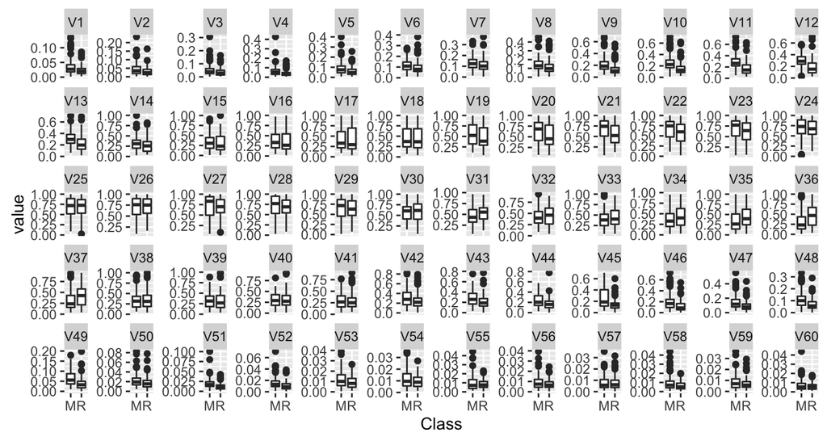

```r
library(ggplot2);library(reshape2) #install.packages(c("ggplot2","reshape2"))
Sonar.m<-melt(Sonar,id.vars = c("Class"))
ggplot(Sonar.m)+geom_boxplot(aes(x=Class,y=value))+
    facet_wrap(~variable, nrow=5,scales = "free_y") #投影片太小了
```

## 步驟1.2: 資料前處理

- 缺值？
  - 沒有缺值，不需要處理
- 答案種類？
  - 類別變項叫`Class`，M: mine礦–>+, R: rock–>-，不需要處理
- 類別變項的型別是不是factor？
  - 是，不需要處理
- 有沒有無關的參數？
  - 沒有無關的參數，不需要處理

## 步驟2:分成訓練組與測試組

該怎麼分可以自己決定，1/3，1/5…都可以

```r
Sonar$Test<-F #新增一個參數紀錄分組
#隨機取1/3當Test set
Sonar[sample(1:nrow(Sonar),nrow(Sonar)/3),]$Test<-T
# 看一下 Training set : Test set 案例數
c(sum(Sonar$Test==F),sum(Sonar$Test==T))
```

```
## [1] 139  69
```

## 步驟3:訓練模型

- 注意只能用`訓練組`的資料，`Test`參數==F，忘記可以看前面範例
- 數值自變項X很多，先用迴歸好了～
- 要解釋一下模型

```r
fit<-glm(Class~., Sonar[Sonar$Test==F,],family="binomial")
finalFit<-stepAIC(fit,direction = "both",trace = F)
summary(finalFit)$coefficients
```

```
##             Estimate Std. Error z value Pr(>|z|)
## (Intercept)     6263     224983   0.028     0.98
## V1            -68618    2330167  -0.029     0.98
## V3             17200    1029206   0.017     0.99
## V7              8731     247452   0.035     0.97
## V12           -12176     375807  -0.032     0.97
## V14             7818     226153   0.035     0.97
## V16             3444     155380   0.022     0.98
## V20            -1043      47856  -0.022     0.98
## V23            -6360     195140  -0.033     0.97
## V30           -10387     324459  -0.032     0.97
## V31            12464     384115   0.032     0.97
## V36             3721     108119   0.034     0.97
## V49           -68844    1963517  -0.035     0.97
## V50           132548    3964895   0.033     0.97
## V52          -210918    6360200  -0.033     0.97
## V55            90933    2545331   0.036     0.97
## V58          -142031    4975388  -0.029     0.98
## V60           -77364    2254476  -0.034     0.97
```

## 步驟4.1:用測試組驗證模型-預測

```r
MinePred<-predict(finalFit,newdata = Sonar[Sonar$Test==T,])
MineAns<-ifelse(MinePred<0.5,"M","R") #<0.5: Level 1
MineAns<-factor(MineAns,levels = c("M","R"))
MineAns
```

```
##   1   2  10  13  14  21  22  25  28  35  36  37  39  40  49  50  54  55
##   M   R   M   M   M   R   R   R   M   R   M   M   M   M   M   R   M   M
##  63  65  70  74  75  77  81  85  88  89  90  94  97 101 102 104 105 112
##   M   M   R   R   M   M   M   R   R   R   R   M   M   R   M   M   M   R
## 114 118 119 123 124 128 130 133 134 135 136 137 138 143 151 153 158 159
##   M   R   M   M   M   R   M   M   M   M   M   M   R   M   M   M   M   M
## 161 166 168 172 178 181 183 188 189 196 197 199 200 204 208
##   M   M   M   M   R   M   R   R   R   R   M   R   M   M   M
## Levels: M R
```

## 步驟4.2:用測試組驗證模型-效能

```r
library(caret) # install.packages("caret") #計算參數的packages
sensitivity(MineAns,Sonar[Sonar$Test==T,]$Class)
```

```
## [1] 0.95
```

```r
specificity(MineAns,Sonar[Sonar$Test==T,]$Class)
```

```
## [1] 0.84
```

```r
posPredValue(MineAns,Sonar[Sonar$Test==T,]$Class)
```

```
## [1] 0.91
```

```r
negPredValue(MineAns,Sonar[Sonar$Test==T,]$Class)
```

```
## [1] 0.91
```

## 解釋範例 - 資料說明

此資料來源為UCI Machine Learning Repository。

記載礦物與石頭接受各個不同角度的聲波撞擊後，接收到的回聲數值，一共有60個參數，代表使用一特別角度的聲波撞擊礦石所得回聲。另外，分類結果為二元分類，包括礦物 (M) 與石頭 (R) 。

## 作業7範例 - 完整的Rmd & md檔

範例是用`"礦石"`資料，跟作業不同，要參考的話記得要改說明/資料來源….等等等

[Rmd下載](https://github.com/yijutseng/BigDataCGUIM/blob/master/HW7.Rmd)

[md下載](https://github.com/yijutseng/BigDataCGUIM/blob/master/HW7.md)